# **Final Project: Missing Children Cases**

Kyle Dalal, Kate Dembny, Carol Huang, and Weiyi Wang

May 3, 2017

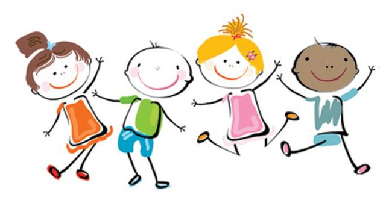

# **INTRODUCTION**

Each year, thousands of children are reported missing, an issue prevalent across the United States. Typically, the words “missing child” are associated with crimes of kidnapping and murder. However, a child can be reported missing for a variety of reasons. It is important to understand these reasons in order to better address the issue at hand. For our final project, we used data about reported missing children to create interesting visualizations in Tableau and R.

# **DATA SOURCE**

We obtained our data from data.world. Specifically from a user by the name of jamesgray, the data set missing-children-in-the-us was downloaded as our dataset. This data was extracted from The National Center for Missing and Exploited Children (NCMEC). It was released as part of the Cloudera Child Finder Hackathon to develop new methods for finding missing children. The dataset can be found [here](https://data.world/jamesgray/missing-children-in-the-us).

# **ETL**

In order to better create and format the data regarding missing children, we built a ETL script to clean-up the data. The source code can be seen below.

```r
source("../01 Data/R_ETL_Final.R")
```

For the ETL script, the first step involved separating the data into measures and dimensions as the clean-up varied depending on its content. Dimensiona are non-numeric values while measures are numeric values. For the dimensions, we removed any hyphens, changed the & symbol to the word “and” and replaced any NULL values with an empty string. Hyphens were removed more for aesthetics. Similarly, changing the & symbol to the word “and” was also another aesthetic item. In contrast, replacing any NULL values with an empty string allowed for better processing of the data. NULL exists for values that are unknown in the data; however, the presence of a NULL causes analysis to be more difficult to do. By removing these and simply replacing them with an empty string, the data is able to be analyzed with ease. As for the measures, we removed any non-numeric or numerically associated values. We kept numbers, the letter e for scientific notation, and any periods for decimals. The presence of non-numeric values or numerically related values will result in an error when attempting to make visualizations using the data. The measures were then set as numeric values. This file was then written to a new csv file. The ETL script code is displayed below.

```r
require(readr)
require(plyr)

# Set the Working Directory to the 00 Doc folder

file_path = "../01 Data/PreETL_MediaReadyActiveCases.csv"
df <- readr::read_csv(file_path)


measures <- c("childid", "height-in", "weight","ncmeccasenumber")
dimensions <- setdiff(names(df), measures)


for(n in names(df)) {
  df[n] <- data.frame(lapply(df[n], gsub, pattern="[^ -~]",replacement= ""))
}


if( length(dimensions) > 0) {
  for(d in dimensions) {
    df[d] <- data.frame(lapply(df[d], gsub, pattern="-",replacement=""))
    df[d] <- data.frame(lapply(df[d], gsub, pattern="&",replacement= " and "))
    df[d] <- data.frame(lapply(df[d], gsub, pattern="NULL",replace=""))
  }
}

na2zero <- function (x) {
  x[is.na(x)] <- "0"
  return(x)
}

if( length(measures) > 1) {
  for(m in measures) {
    df[m] <- data.frame(lapply(df[m], na2zero))
    df[m] <- data.frame(lapply(df[m], gsub, pattern="[^.,0-9,e]",replacement= ""))
    df[m] <- data.frame(lapply(df[m], function(x) as.numeric(as.character(x))))

  }
}

write.csv(df, gsub("PreETL_", "", file_path), row.names=FALSE, na = "")
```

# **THE DATA**

These graphs show some of the interesting findings found in this data.

## **Box Plots**

### **Figure 1: Visualization 1 - Tableau Visualization**

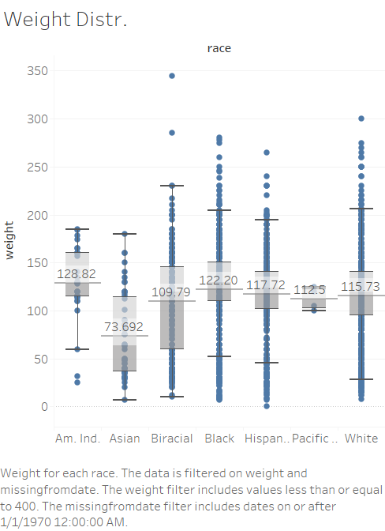

### **Figure 2: Visualization 1 - Shiny Visualization**

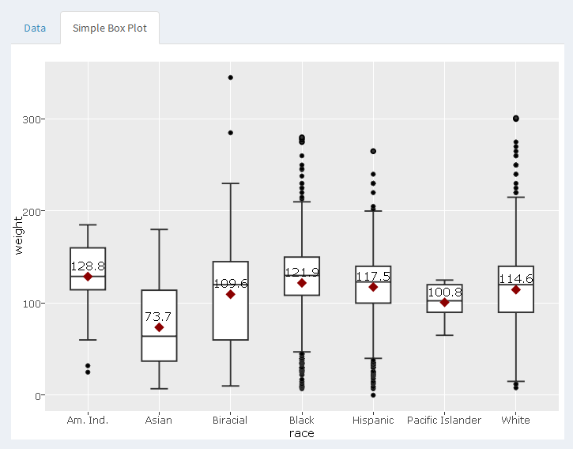

Figure 1 and Figure 2 show a box plot of the different races with the data summarized based on weight. Each box plot includes the 5 number summary: minimum, first quartile, median, third quartile, and maximum. They are filtered by weight and missing from date.

An interesting thing to note from the box plots is clicking through the states, some states do not have reported missing children of certain race. However, the white children are almost always shown in the box plots. For many of them, the box plot for white children has the largest distribution between minimum and maximum.

## **Histograms**

### **Figure 3: Visualization 2 - Tableau Visualization**

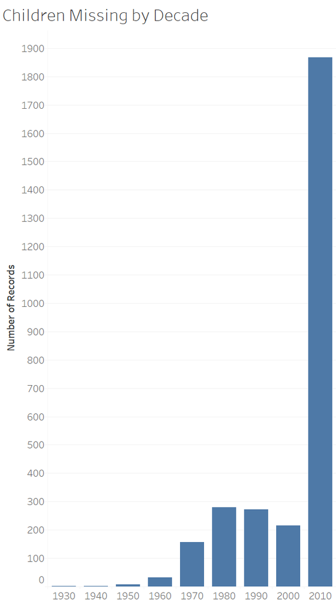

### **Figure 4: Visualization 2 - Shiny Visualization**

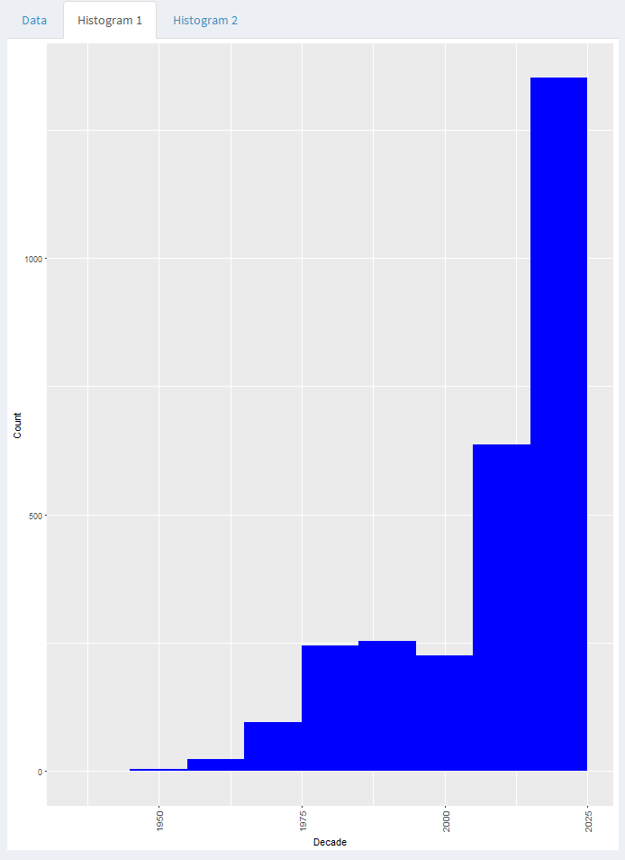

Figure 3 and Figure 4 show a histogram of the number of recorded missing children in 10 year increments with regards to the missing from date.

An interesting thing to note from the histogram is that for the most part, the number of children that have gone missing has increased over the years. An abnormal point in time is in the 2000’s. The number of missing children decreases and breaks the trend. However in the 2010’s the number spikes and increases exponentially.

### **Figure 5: Visualization 3 - Tableau Visualization**

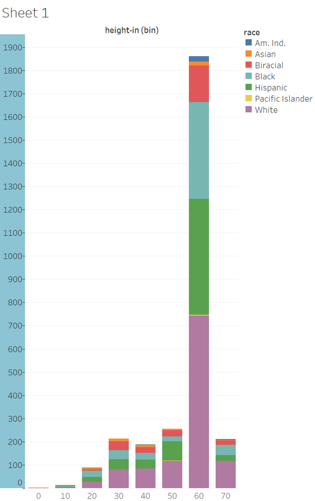

### **Figure 6: Visualization 3 - Shiny Visualization**

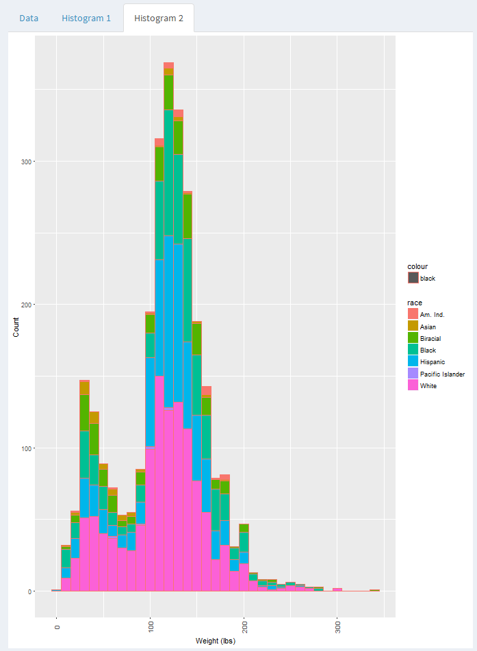

Figure 5 and Figure 6 show a histogram of the number of recorded missing children separated based on their height (for the Tableau visualization) and weight (for the Shiny visualization). It is further divided by race as each race is represented by a different color on the histogram as seen in the legend.

An interesting thing to note from the histogram is that similar to the box plots, the color for white children is substantially larger than those for other races. However, looking at this specific visualization, one is able to see that although white children are most likely to go missing, Hispanic children fall in close 2nd.

## **Scatterplots**

### **Figure 7: Visualization 4 - Tableau Visualization**

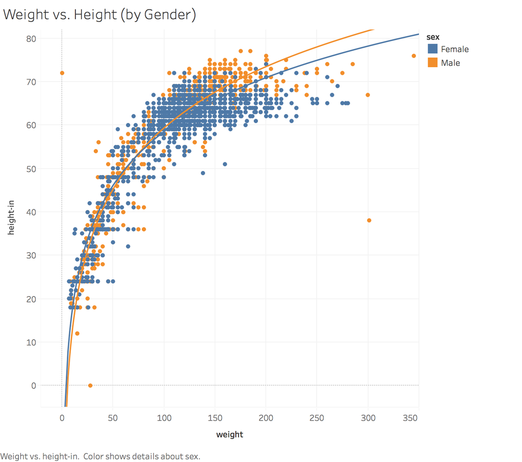

### **Figure 8: Visualization 4 - Shiny Visualization**

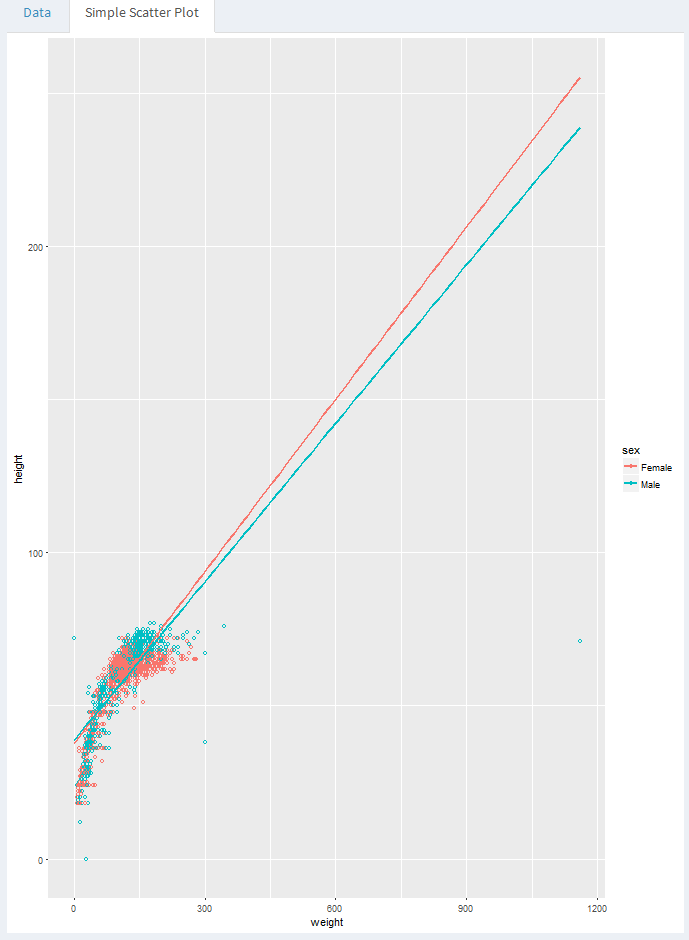

Figure 7 and 8 shows a scatterplot that compares missing children weight (x-axis) versus height (y-axis) colored by gender.

## **Crosstabs**

### **Figure 9: Visualization 5 - Tableau Visualization**

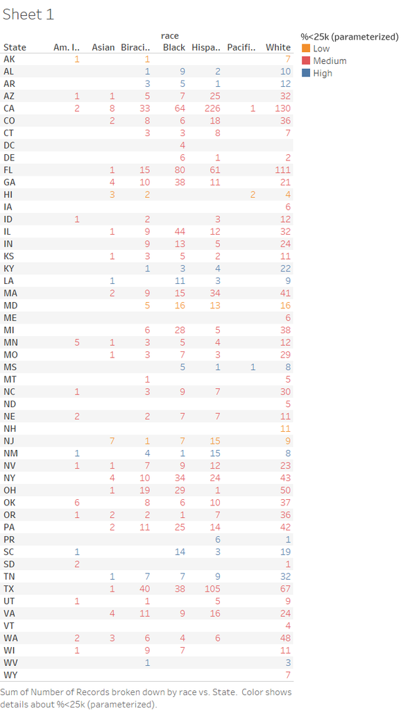

### **Figure 10: Visualization 5 - Shiny Visualization**

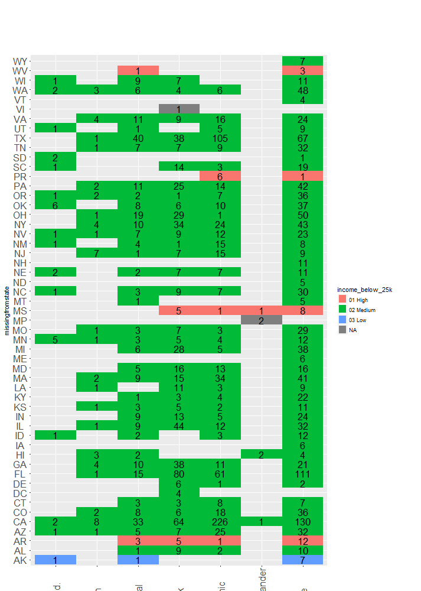

An interesting thing to note is that the majority of the childrens that go missing are from the middle range income. This is apparent across the majority of the states.

## **Barcharts**

### **Figure 11: Visualization 6 - Tableau Visualization**

[figure not shown]

### **Figure 12: Visualization 6 - Shiny Visualization**

[figure not shown]

### **Figure 13: Visualization 7 - Tableau Visualization High**

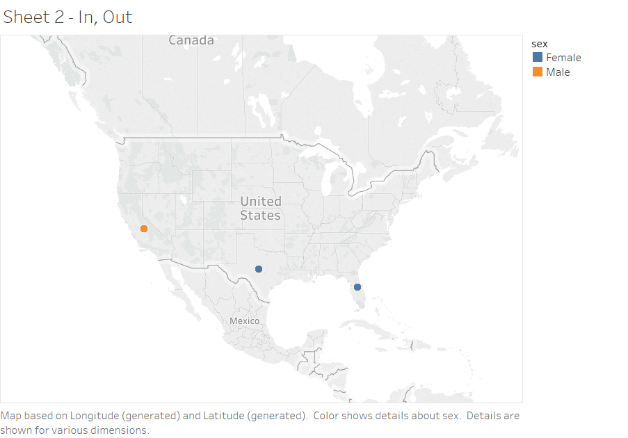

### **Figure 14: Visualization 7 - Tableau Visualization Medium**

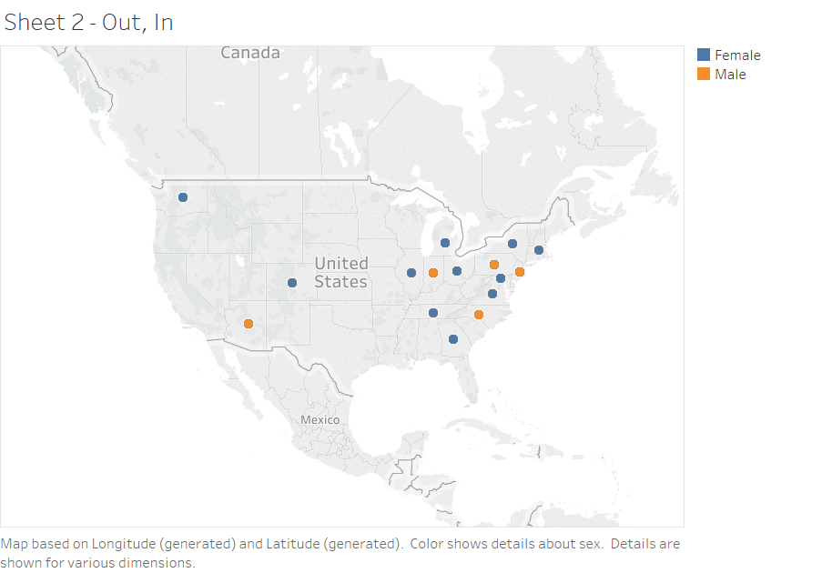

### **Figure 15: Visualization 7 - Tableau Visualization Low**

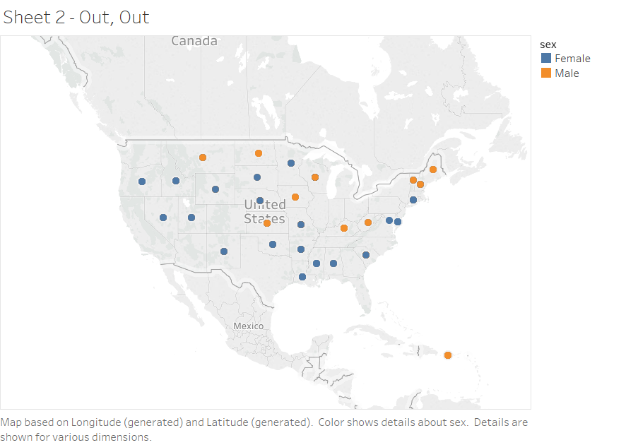

### **Figure 16: Visualization 7 - Shiny Visualization**

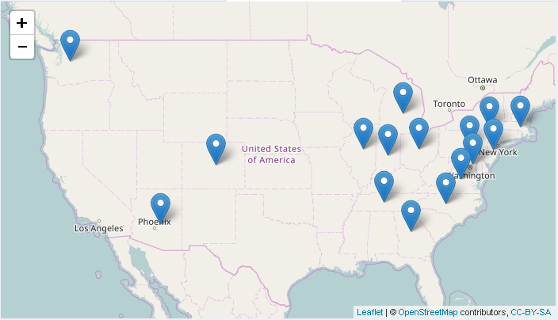

Figure 13 to 16 show a geographic fields map based on longitude and latitude. The color on the map differentiates between whether females or males are the sex of the majority of the children that have gone missing. A set was made from a barchart of missingfromstate vs. the sum of people with bachelor’s degrees in each state. This data was created by joining the MediaReadyActiveCases with the Education data from the US Census Data. The Shiny Visualization set consists of the “Medium” group with bachelor’s degrees. This set was then plotted on the map. The Tableau Visualization shows all 3 sets, high amount of bachelor’s degree, medium, and low.

Figures 2, 4, 6, 8, 10, 12, and 16 has been published to the following shiny.ios app: https://carolhuang0502.shinyapps.io/finalproject/

# **Source Code**

## **Shiny server.R and ui.R Source Code**

```r
source("../02 Shiny/server.R")
source("../02 Shiny/ui.R")
```

## **Shiny server.R Code**

```r
# server.R
require(ggplot2)
require(dplyr)
require(shiny)
require(shinydashboard)
require(data.world)
require(readr)
require(DT)
require(leaflet)
require(plotly)

shinyServer(function(input, output) {

  online3 = reactive({input$rb1})
  income_below_25k_Low = reactive({input$income_below_25k_low})
  income_below_25k_Medium = reactive({input$income_below_25k_medium})

  # These widgets are for the Barcharts tab.
  online2 = reactive({input$rb2})
  output$races2 <- renderUI({selectInput("selectedraces", "Choose Races:", race_list, multiple = TRUE, selected='All') })


  # The following query is for the select list in the Barcharts -> Barchart with Table Calculation tab.
  races = query(
    data.world(propsfile = "www/.data.world"),
    dataset="carolhuang0502/s-17-dv-final-project", type="sql",
    query="select distinct race as D, race as R
    from MediaReadyActiveCases
    order by 1"
  ) # %>% View()
  if(races[1] == "Server error") {
    print("Getting races from csv")
    file_path = "../01 Data/MediaReadyActiveCases.csv"
    df <- readr::read_csv(file_path)
    tdf1 = df %>% dplyr::distinct(race) %>% arrange(race) %>% dplyr::rename(D = race)
    tdf2 = df %>% dplyr::distinct(race) %>% arrange(race) %>% dplyr::rename(R = race)
    races = bind_cols(tdf1, tdf2)
  }
  race_list <- as.list(races$D, races$R)
  race_list <- append(list("All" = "All"), race_list)

  # The following query is for the select list in the Barcharts -> Medium Bachelors Degree Level
  degrees = query(
    data.world(propsfile = "www/.data.world"),
    dataset="carolhuang0502/s-17-dv-project-6", type="sql",
    query="SELECT sex, casetype, missingfromcity, educationqueryresult.State, bachelors_degree, state_lat_long.State as state, Latitude, Longitude, sum(bachelors_degree) as sum_bac
    FROM MediaReadyActiveCases s inner join
    educationqueryresult a
    ON (s.missingfromstate = a.State) inner join
    state_lat_long c
    ON (s.missingfromstate = c.State)
    where c.State in (a.State)
    group by missingfromstate
    having sum(bachelors_degree)> 32000000 and sum(bachelors_degree)< 490000000"

  )  # %>% View()

  # The following query is for hte select list in the Barcharts -> Missing By Year
  sales = query(
    data.world(propsfile = "www/.data.world"),
    dataset="carolhuang0502/s-17-dv-final-project", type="sql",
    query="select CAST (year(CAST (missingreporteddate AS date)) as string) as year, count(childid) as record
    from MediaReadyActiveCases
    group by CAST (year(CAST (missingreporteddate AS date)) as string)
    order by year"
  ) # %>% View()


# Begin Box Plot Tab ------------------------------------------------------------------
dfbp1 <-

  query(
    data.world(propsfile = "www/.data.world"),
    dataset="carolhuang0502/s-17-dv-final-project", type="sql",
    query="select weight,race,missingfromdate
    from MediaReadyActiveCases
    where weight<400") # %>% View()


output$boxplotData1 <- renderDataTable({DT::datatable(dfbp1, rownames = FALSE,
                                                      extensions = list(Responsive = TRUE,
                                                                        FixedHeader = TRUE)
)
})



output$boxplotPlot1 <- renderPlotly({
  means <- aggregate(weight ~ race,dfbp1, mean)

  rounded_means <- round(means$weight,1)

  means$weight <- rounded_means
  p <- ggplot(dfbp1, aes(x=race,y=weight)) +
    geom_boxplot() +
    stat_summary(fun.y = "mean", colour="darkred", geom="point", shape=18, size=2,show_guide = FALSE) +
    geom_text(data = means, aes(label = weight, y = weight+10))
  ggplotly(p)
})
# End Box Plot Tab ___________________________________________________________

  # Begin Histogram Tab ------------------------------------------------------------------
  dfh1 <-   query(
    data.world(propsfile = "www/.data.world"),
    dataset="carolhuang0502/s-17-dv-final-project", type="sql",
    query="select year
    from Year_query") # %>% View()
  output$histogramData1 <- renderDataTable({DT::datatable(dfh1,
                                                       rownames = FALSE,
                                                       extensions = list(Responsive = TRUE, FixedHeader = TRUE) )
  })
  output$histogramPlot1 <- renderPlot({ggplot(dfh1) +
      geom_histogram(aes(x=dfh1), binwidth = 10, fill = I("blue")) + labs(x = "Decade", y = "Count") +
      theme(axis.text.x=element_text(angle=90, size=10, vjust=0.5))
  })

  dfh2 <-   query(
    data.world(propsfile = "www/.data.world"),
    dataset="carolhuang0502/s-17-dv-final-project", type="sql",
    query="select weight, race
    from MediaReadyActiveCases
    where weight < 500") # %>% View()
  output$histogramData2 <- renderDataTable({DT::datatable(dfh2,
                                                          rownames = FALSE,
                                                          extensions = list(Responsive = TRUE, FixedHeader = TRUE) )
  })
  output$histogramPlot2 <- renderPlot({ggplot(dfh2) + geom_histogram(aes(x=weight, fill=race, color="black"), binwidth = 10) + labs(x = "Weight (lbs)", y = "Count")+
    theme(axis.text.x=element_text(angle=90, size=10, vjust=0.5))

  })

  # End Histogram Tab ___________________________________________________________
  # Begin Scatterplot Tab ------------------------------------------------------------------
  dfs1 <- eventReactive(input$click3, {
    print("Getting from data.world")
    query(
      data.world(propsfile = "www/.data.world"),
      dataset="carolhuang0502/s-17-dv-final-project", type="sql",
      query="select `height-in` as height, weight, sex
      from MediaReadyActiveCases"
    )
  })

  output$scatterData1 <- renderDataTable({DT::datatable(dfs1(), rownames = FALSE, extensions = list(Responsive = TRUE, FixedHeader = TRUE))})
  output$scatterPlot1 <- renderPlot({ggplot(dfs1(),aes(x=weight, y=height, color = sex))+
      geom_point(shape = 1) +
      geom_smooth(method=lm, se=FALSE, fullrange=TRUE)
  })
  # End Scatterplot Tab ___________________________________________________________
  # Begin Crosstab 1 Tab ------------------------------------------------------------------
  df1 <- eventReactive(input$click1, {
```

```r
    print("Getting from data.world")
    query(
      data.world(propsfile = "www/.data.world"),
      dataset="carolhuang0502/s-17-dv-project-5", type="sql",
      query="select missingfromstate, race, count, hh_0k_to_25k,total_households, hh_0k_to_25k/total_households as Perc_Below_25k,

      case
      when hh_0k_to_25k/total_households < ? then '03 Low'
      when hh_0k_to_25k/total_households < ? then '02 Medium'
      else '01 High'
      end AS income_below_25k

      from cleanedracedata
      left join incomequeryresult
      on missingfromstate= State",
      queryParameters = list(income_below_25k_Low(), income_below_25k_Medium())

    )


  })
  output$data1 <- renderDataTable({DT::datatable(df1(), rownames = FALSE,
                                                 extensions = list(Responsive = TRUE, FixedHeader = TRUE)
  )
  })
  output$plot1 <- renderPlot({ggplot(df1()) +
      theme(axis.text.x=element_text(angle=90, size=16, vjust=0.5)) +
      theme(axis.text.y=element_text(size=16, hjust=0.5)) +
      geom_tile(aes(x=race, y=missingfromstate, fill = income_below_25k), size=6)+
      geom_text(aes(x=race, y=missingfromstate, label=count), size=6)

  })
  # End Crosstab 1 Tab ___________________________________________________________

  # Begin Barchart Tab ------------------------------------------------------------------
  df2 <- eventReactive(input$click2, {
    if(input$selectedraces == 'All') race_list <- input$selectedraces
    else race_list <- append(list("Skip" = "Skip"), input$selectedraces)
    if(online2() == "SQL") {
      print("Getting from data.world")
      tdf = query(
        data.world(propsfile = "www/.data.world"),
        dataset="carolhuang0502/s-17-dv-final-project", type="sql",
        query="select missingfromstate, race, count(childid) count_childid
        from MediaReadyActiveCases
        where ? = 'All' or race in (?, ?, ?, ?, ?, ?, ?, ?, ?, ?, ?, ?, ?, ?, ?, ?, ?, ?, ?, ?, ?)
        group by missingfromstate, race",
        queryParameters = race_list
      ) # %>% View()
    }
    else {
      print("Getting from csv")
      file_path = "../01 Data/MediaReadyActiveCases.csv"
      df <- readr::read_csv(file_path)
      tdf = df %>% dplyr::filter(race %in% input$selectedraces | input$selectedraces == "All") %>%
        dplyr::group_by(missingfromstate, race) %>%
        dplyr::summarize(count_childid = count(childid)) # %>% View()
    }
    # The following two lines mimic what can be done with Analytic SQL. Analytic SQL does not currently work in data.world.
    tdf2 = tdf %>% group_by(missingfromstate) %>% summarize(window_count_childid = mean(count_childid))
    dplyr::inner_join(tdf, tdf2, by = "missingfromstate")
    # Analytic SQL would look something like this:
    # select missingfromstate, race, count_childid, avg(count_childid)
    # OVER (PARTITION BY missingfromstate ) as window_avg_childid
    # from (select missingfromstate, race, count(childid) count_childid
    #       from MediaReadyActiveCases
    #      group by missingfromstate, race)
  })

  output$barchartData1 <- renderDataTable({DT::datatable(df2(),
                                                         rownames = FALSE,
                                                         extensions = list(Responsive = TRUE, FixedHeader = TRUE) )
  })
  output$barchartData2 <- renderDataTable({DT::datatable(degrees,
                                                         rownames = FALSE,
                                                         extensions = list(Responsive = TRUE, FixedHeader = TRUE) )
  })
  output$barchartData3 <- renderDataTable({DT::datatable(sales,
                                                         rownames = FALSE,
                                                         extensions = list(Responsive = TRUE, FixedHeader = TRUE) )
  })
  output$barchartPlot1 <- renderPlot({ggplot(df2(), aes(x=race, y=count_childid)) +
      scale_y_continuous(labels = scales::comma) + # no scientific notation
      theme(axis.text.x=element_text(angle=0, size=12, vjust=0.5)) +
      theme(axis.text.y=element_text(size=12, hjust=0.5)) +
      geom_bar(stat = "identity") +
      facet_wrap(~missingfromstate, ncol=1) +
      coord_flip() +
      # Add count_childid, and (count_childid - window_avg_childid) label.
      geom_text(mapping=aes(x=race, y=count_childid, label=round(count_childid, digits = 1)),colour="black", hjust=-.5) +
      geom_text(mapping=aes(x=race, y=count_childid, label=round(window_count_childid - count_childid, digits = 1)),colour="blue", hjust=-2) +
      # Add reference line with a label.
      geom_hline(aes(yintercept = round(window_count_childid)), color="red") +
      geom_text(aes( -1, window_count_childid, label = window_count_childid, vjust = -.5, hjust = -.25), color="red")
  })
  output$barchartMap1 <- renderLeaflet({leaflet(width = 400, height = 800) %>%
      setView(lng = -98.35, lat = 39.5, zoom = 4) %>%
      addTiles() %>%
      addMarkers(lng = degrees$Longitude,
                 lat = degrees$Latitude,
                 options = markerOptions(draggable = TRUE, riseOnHover = TRUE),
                 popup = as.character(paste("City: " , degrees$missingfromcity,
                                            ", State: ", degrees$missingfromcity,
                                            ", Case Type: ", degrees$casetype,
                                            ", Sex: ", degrees$sex
                 )) )
  })
  output$barchartPlot2 <- renderPlotly({p <- ggplot(sales, aes(x=as.character(year), y=record)) +
    theme(axis.text.x=element_text(angle=0, size=7, vjust=0.5)) +
    theme(axis.text.y=element_text(size=12, hjust=0.5)) +
    geom_bar(stat = "identity")+
    xlab("\nYear")+ylab("\nRecord")
  ggplotly(p)
  })

  # End Barchart Tab ___________________________________________________________

  })
```

## **Shiny ui.R Code**

```r
#ui.R
require(shiny)
require(shinydashboard)
require(DT)
require(leaflet)
require(plotly)

dashboardPage(
  dashboardHeader(
  ),
  dashboardSidebar(
    sidebarMenu(
      menuItem("Box Plots", tabName = "boxplot", icon = icon("dashboard")),
      menuItem("Histograms", tabName = "histogram", icon = icon("dashboard")),
      menuItem("Scatter Plots", tabName = "scatter", icon = icon("dashboard")),
      menuItem("Crosstabs, KPIs, Parameters", tabName = "crosstab", icon = icon("dashboard")),
      menuItem("Barcharts, Table Calculations", tabName = "barchart", icon = icon("dashboard"))
    )
  ),
  dashboardBody(
    tags$style(type="text/css",
               ".shiny-output-error { visibility: hidden; }",
               ".shiny-output-error:before { visibility: hidden; }"
    ),
    tabItems(
      # Begin Box Plots tab content.
      tabItem(tabName = "boxplot",
              tabsetPanel(
                tabPanel("Data",

                         DT::dataTableOutput("boxplotData1")
                ),
                tabPanel("Simple Box Plot",

                         plotlyOutput("boxplotPlot1", height=500))
              )
      ),
      # End Box Plots tab content.
      # Begin Histogram tab content.
      tabItem(tabName = "histogram",
              tabsetPanel(
                tabPanel("Data",

                         DT::dataTableOutput("histogramData1"),
                         hr(),
                         DT::dataTableOutput("histogramData2")
                ),
                tabPanel("Histogram 1", plotOutput("histogramPlot1", height=900)),
                tabPanel("Histogram 2 ", plotOutput("histogramPlot2", height=900))
              )
      ),
      # End Histograms tab content.
      # Begin Scatter Plots tab content.
      tabItem(tabName = "scatter",
              tabsetPanel(
                tabPanel("Data",
                         radioButtons("rb3", "Get data from:",
                                      c("SQL" = "SQL",
                                        "CSV" = "CSV"), inline=T),
                         uiOutput("scatterStates"), # See http://shiny.rstudio.com/gallery/dynamic-ui.html,
                         actionButton(inputId = "click3",  label = "To get data, click here"),
                         hr(), # Add space after button.
                         DT::dataTableOutput("scatterData1")
                ),
                tabPanel("Simple Scatter Plot", plotOutput("scatterPlot1", height=900))
              )
      ),
      # End Scatter Plots tab content.
      # Begin Crosstab tab content.
      tabItem(tabName = "crosstab",
              tabsetPanel(
                tabPanel("Data",
                         radioButtons("rb1", "Get data from:",
                                      c("SQL" = "SQL"), inline=T),
                         sliderInput("income_below_25k_low", "income_below_25k_Low:",
                                     min = 0, max = .15,  value = .15),
                         sliderInput("income_below_25k_medium", "income_below_25k_Medium:",
                                     min = .15, max = .3,  value = .3),
                         actionButton(inputId = "click1",  label = "To get data, click here"),
                         hr(), # Add space after button.
                         DT::dataTableOutput("data1")
                ),
                tabPanel("Crosstab", plotOutput("plot1", height=1000))
              )
      ),
      # End Crosstab tab content.
      # Begin Barchart tab content.
      tabItem(tabName = "barchart",
              tabsetPanel(
                tabPanel("Data",
                         radioButtons("rb2", "Get data from:",
                                      c("SQL" = "SQL",
                                        "CSV" = "CSV"), inline=T),
                         uiOutput("races2"), # See http://shiny.rstudio.com/gallery/dynamic-ui.html
                         actionButton(inputId = "click2",  label = "To get data, click here"),
                         hr(), # Add space after button.
                         'Here is data for the "Barchart with Table Calculation" tab',
                         hr(),
                         DT::dataTableOutput("barchartData1"),
                         hr(),
                         'Here is data for the "Medium Bachelors Degree Level" tab',
                         hr(),
                         DT::dataTableOutput("barchartData2"),
                         hr()
                ),
                tabPanel("Race of Missing Children per State with Table Calculation", "Black = Count of Children per Race, Red = Average Count of Children per missingfromstate, and  Blue = (Average Count of Children per Race - Count of Children per Race)", plotOutput("barchartPlot1", height=6000)),
                tabPanel("Medium Bachelors Degree Level", leafletOutput("barchartMap1"), height=900 )
              )
      )
      # End Barchart tab content.
    )
  )
)
```

# **Knit R-markdown into HTML file**